# Pro gradun tilastoanalyysit

Mikael Ovaska

2022-10-20

```r
library(tidyverse)
library(jtools)
library(lme4)
```

```r
library(sjPlot)
library(sjmisc)
library(rstatix)
library(AICcmodavg)
library(moments)
data <- read_delim(file = 'ospan_and_survey.csv',delim=",")
data
```

```
## # A tibble: 28 × 54
##    subje…¹ score_1 score_2 bal   gender   age vdaq_1 vdaq_2 vdaq_3 vdaq_4 vdaq_5
##      <dbl>   <dbl>   <dbl> <chr>  <dbl> <dbl>  <dbl>  <dbl>  <dbl>  <dbl>  <dbl>
##  1       2      19      25 b          1    31      3      3      3      4      4
##  2       3      18      21 a          1    26      3      4      4      4      4
##  3       4      26      26 b          1    28      3      1      4      4      2
##  4       5      22      21 a          2    26      3      4      2      3      4
##  5       6      28      30 b          2    25      3      2      4      2      2
##  6       8      30      28 b          1    30      3      3      4      3      4
##  7       9      30      26 a          2    26      3      2      2      4      3
##  8      10      30      30 b          2    23      3      3      1      2      4
##  9      11      25      30 a          2    22      3      2      3      4      4
## 10      12      29      30 b          2    21      3      4      2      4      4
## # … with 18 more rows, 43 more variables: vdaq_6 <dbl>, vdaq_7 <dbl>,
## #   vdaq_8 <dbl>, vdaq_9 <dbl>, vdaq_10 <dbl>, vdaq_11 <dbl>, vdaq_12 <dbl>,
## #   vdaq_13 <dbl>, vdaq_14 <dbl>, vdaq_15 <dbl>, vdaq_16 <dbl>, asq_1 <dbl>,
## #   asq_2 <dbl>, asq_3 <dbl>, asq_4 <dbl>, asq_5 <dbl>, asq_6 <dbl>,
## #   asq_7 <dbl>, asq_8 <dbl>, asq_9 <dbl>, asq_10 <dbl>, asq_11 <dbl>,
## #   asq_12 <dbl>, ovs_1 <dbl>, ovs_2 <dbl>, ovs_3 <dbl>, ovs_4 <dbl>,
## #   ovs_5 <dbl>, ovs_6 <dbl>, ovs_7 <dbl>, ovs_8 <dbl>, ovs_9 <dbl>, …
```

## 0.1 Aineiston rajaus

Rajun kattoefektin takia luodaan ainestosta kaksi versiota.

```r
data.1_30 <- data
data.e_30 <- data %>% filter(score_1<30 & score_2<30)

data.1_30long <- pivot_longer(data.1_30, cols=2:3, names_to = 'Task', values_to = "Score")
data.ei_30long <- pivot_longer(data.e_30, cols=2:3, names_to = 'Task', values_to = "Score")

data.30 <- select(data.1_30long, subjectId, Score, Task, bal, gender, age,
                   ovs, ovs_salience, ovs_reactibility, ovs_monitoring,
                   asq, asq_int, asq_ext, vdaq)

data.ei_30 <- select(data.ei_30long, subjectId, Score, Task, bal, gender, age,
                   ovs, ovs_salience, ovs_reactibility, ovs_monitoring,
                   asq, asq_int, asq_ext, vdaq)

data.30 #koko
```

```
## # A tibble: 56 × 14
##    subjectId Score Task   bal   gender   age   ovs ovs_s…¹ ovs_r…² ovs_m…³   asq
##        <dbl> <dbl> <chr>  <chr>  <dbl> <dbl> <dbl>   <dbl>   <dbl>   <dbl> <dbl>
##  1         2    19 score… b          1    31  2.25    2       2.5     2.25  4.33
##  2         2    25 score… b          1    31  2.25    2       2.5     2.25  4.33
##  3         3    18 score… a          1    26  3.58    3       4.25    3.5   4.08
##  4         3    21 score… a          1    26  3.58    3       4.25    3.5   4.08
##  5         4    26 score… b          1    28  3.08    2       3       4.25  4.17
##  6         4    26 score… b          1    28  3.08    2       3       4.25  4.17
##  7         5    22 score… a          2    26  3.42    4.25    4       2     5.17
##  8         5    21 score… a          2    26  3.42    4.25    4       2     5.17
##  9         6    28 score… b          2    25  3       2.75    3       3.25  3.67
## 10         6    30 score… b          2    25  3       2.75    3       3.25  3.67
## # … with 46 more rows, 3 more variables: asq_int <dbl>, asq_ext <dbl>,
## #   vdaq <dbl>, and abbreviated variable names ¹ovs_salience,
## #   ²ovs_reactibility, ³ovs_monitoring
```

```r
data.ei_30 #30 edes toisessa poistettu
```

```
## # A tibble: 36 × 14
##    subjectId Score Task   bal   gender   age   ovs ovs_s…¹ ovs_r…² ovs_m…³   asq
##        <dbl> <dbl> <chr>  <chr>  <dbl> <dbl> <dbl>   <dbl>   <dbl>   <dbl> <dbl>
##  1         2    19 score… b          1    31  2.25    2       2.5     2.25  4.33
##  2         2    25 score… b          1    31  2.25    2       2.5     2.25  4.33
##  3         3    18 score… a          1    26  3.58    3       4.25    3.5   4.08
##  4         3    21 score… a          1    26  3.58    3       4.25    3.5   4.08
##  5         4    26 score… b          1    28  3.08    2       3       4.25  4.17
##  6         4    26 score… b          1    28  3.08    2       3       4.25  4.17
##  7         5    22 score… a          2    26  3.42    4.25    4       2     5.17
##  8         5    21 score… a          2    26  3.42    4.25    4       2     5.17
##  9        13    17 score… a          1    55  1.58    1.25    2       1.5   3.5
## 10        13    13 score… a          1    55  1.58    1.25    2       1.5   3.5
## # … with 26 more rows, 3 more variables: asq_int <dbl>, asq_ext <dbl>,
## #   vdaq <dbl>, and abbreviated variable names ¹ovs_salience,
## #   ²ovs_reactibility, ³ovs_monitoring
```

```r
data.30$Task <- relevel(as_factor(data.30$Task), ref = "score_2")
data.ei_30$Task <- relevel(as_factor(data.ei_30$Task), ref = "score_2")
```

## 0.2 Muuttujien hierarkia

Kuvassa on esitetty kuinka aineiston muuttujat ovat suhteessa toisiinsa.

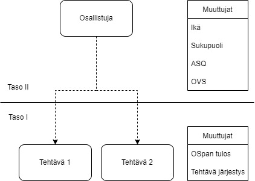

Muuttujat

### 0.2.1 Kuinka counterbalanssi tulee mallintaa?

Notebookkiin tuodussa muuttujassa ‘bal’ on seuraava koodaus:

a(cond 1-> cond 2), b(cond 2 -> cond 1)

Eli balanssissa ‘a’ tehtävä suoritettiin ensin puhelimen läsnäollessa ja ‘b’ puhelimen ollessa selän takana. Näin koodattuna lme4 kuitenkin luulee sen olevan kakkostason muuttuja, jolloin se liittyisi osallistujaan. Sen tulisi olla tasolla 1, koska se on mittaukseen liittyvä muuttuja eikä osallistujaan. Koodaamalla se uudestaan se voidaan tiputtaa tasolle 1.

Luodaan ‘bal’ muuttujasta uusi muuttuja, joka kuvaa oliko havainto tehtävistä osallistujan ensimmäinen vai toinen suoritus.

```r
data.30 <- data.30 %>% mutate(Balance = ifelse((Task=='score_1' & bal=='a')| (Task=='score_2' & bal=='b'), 'first', 'second'))
data.ei_30 <- data.ei_30 %>% mutate(Balance = ifelse((Task=='score_1' & bal=='a')| (Task=='score_2' & bal=='b'), 'first', 'second'))
```

### 0.2.2 Datan keskitys ja stantardointi

Lineaari regression vakioiden ja leikkauksen tulkinta on hankalaa, jos sisällytettävillä muuttujilla ei ole selkeää nollakohtaa tai sellaista ei ole määritetty. Psykologisilla mittareilla ja isällä ei ole luonnollista nollakohtaa, joten luodaan niille sellaiset. Muuttujat keskitetään vähentämällä muuttujista niiden keskiarvo. Tällöin koko otoksen keskiarvosta tulee muuttujan nollakohta, jolloin vakioita voidaan tulkita suhteessa koko otoksen keskiarvoon ja leikkauskohta (intercept) kertoo, mikä tehtävän tuloksen arvioidaan olevan muuttujien saadessa niiden keskiarvon. Tällöin leikkauskohta asettuu tulkinnan kannalta mielekkääseen kohtaan.

```r
data.30$age_c <- (data.30$age - mean(data.30$age))

data.30$ovs_c <- (data.30$ovs - mean(data.30$ovs))
data.30$ovs_salience_c <- (data.30$ovs_salience - mean(data.30$ovs_salience))
data.30$ovs_reactibility_c <- (data.30$ovs_reactibility - mean(data.30$ovs_reactibility))
data.30$ovs_monitoring_c <- (data.30$ovs_monitoring - mean(data.30$ovs_monitoring))

data.30$asq_c <- (data.30$asq - mean(data.30$asq))
data.30$asq_ext_c <- (data.30$asq_ext - mean(data.30$asq_ext))
data.30$asq_int_c <- (data.30$asq_int - mean(data.30$asq_int))

data.30$vdaq_c <- (data.30$vdaq - mean(data.30$vdaq))


data.ei_30$age_c <- (data.ei_30$age - mean(data.ei_30$age))

data.ei_30$ovs_c <- (data.ei_30$ovs - mean(data.ei_30$ovs))
data.ei_30$ovs_salience_c <- (data.ei_30$ovs_salience - mean(data.ei_30$ovs_salience))
data.ei_30$ovs_reactibility_c <- (data.ei_30$ovs_reactibility - mean(data.ei_30$ovs_reactibility))
data.ei_30$ovs_monitoring_c <- (data.ei_30$ovs_monitoring - mean(data.ei_30$ovs_monitoring))

data.ei_30$asq_c <- (data.ei_30$asq - mean(data.ei_30$asq))
data.ei_30$asq_ext_c <- (data.ei_30$asq_ext - mean(data.ei_30$asq_ext))
data.ei_30$asq_int_c <- (data.ei_30$asq_int - mean(data.ei_30$asq_int))

data.ei_30$vdaq_c <- (data.ei_30$vdaq - mean(data.ei_30$vdaq))
```

Pelkästään keskittämällä muuttujat ne eivät ole kuitenkaan toistensa kanssa vertailukelpoisia. Tämä saadaan toteutettua stantardisoialla muuttujat, esimerkiksi vähentämällä keskiarvon ja jakamalla kahdella keskihajonnalla. Kahdella keskihajonnalla jaettaessa jatkuvat muuttujat ovat likipitäen vertailukelpoisia binääristen muuttujien kanssa [0]

[0] Gelman, A., Hill, J., & Vehtari, A. (2020). *Regression and other stories*. Cambridge University Press.

```r
data.30$age_z <- (data.30$age - mean(data.30$age))/(2*sd(data.30$age))

data.30$ovs_z <- (data.30$ovs - mean(data.30$ovs))/(2*sd(data.30$ovs))
data.30$ovs_salience_z <- (data.30$ovs_salience - mean(data.30$ovs_salience))/(2*sd(data.30$ovs_salience))
data.30$ovs_reactibility_z <- (data.30$ovs_reactibility - mean(data.30$ovs_reactibility))/(2*sd(data.30$ovs_reactibility))

data.30$ovs_monitoring_z <- (data.30$ovs_monitoring - mean(data.30$ovs_monitoring))/(2*sd(data.30$ovs_monitoring))

data.30$asq_z <- (data.30$asq - mean(data.30$asq))/(2*sd(data.30$asq))
data.30$asq_ext_z <- (data.30$asq_ext - mean(data.30$asq_ext))/(2*sd(data.30$asq_ext))
data.30$asq_int_z <- (data.30$asq_int - mean(data.30$asq_int))/(2*sd(data.30$asq_int))

data.30$vdaq_z <- (data.30$vdaq - mean(data.30$vdaq))/(2*sd(data.30$vdaq))


data.ei_30$age_z <- (data.ei_30$age - mean(data.ei_30$age))/(2*sd(data.ei_30$age))

data.ei_30$ovs_z <- (data.ei_30$ovs - mean(data.ei_30$ovs))/(2*sd(data.ei_30$ovs))
data.ei_30$ovs_salience_z <- (data.ei_30$ovs_salience - mean(data.ei_30$ovs_salience))/(2*sd(data.ei_30$ovs_salience))
data.ei_30$ovs_reactibility_z <- (data.ei_30$ovs_reactibility - mean(data.ei_30$ovs_reactibility))/(2*sd(data.ei_30$ovs_reactibility))

data.ei_30$ovs_monitoring_z <- (data.ei_30$ovs_monitoring - mean(data.ei_30$ovs_monitoring))/(2*sd(data.ei_30$ovs_monitoring))

data.ei_30$asq_z <- (data.ei_30$asq - mean(data.ei_30$asq))/(2*sd(data.ei_30$asq))
data.ei_30$asq_ext_z <- (data.ei_30$asq_ext - mean(data.ei_30$asq_ext))/(2*sd(data.ei_30$asq_ext))
data.ei_30$asq_int_z <- (data.ei_30$asq_int - mean(data.ei_30$asq_int))/(2*sd(data.ei_30$asq_int))

data.ei_30$vdaq_z <- (data.ei_30$vdaq - mean(data.ei_30$vdaq))/(2*sd(data.ei_30$vdaq))
```

## 0.3 Summary

```r
data.ei_30 %>%
  summarise(mean = round(mean(Score), digits = 2),
            sd = round(sd(Score), digits = 2),
            median = median(Score),
            range = paste(min(Score), "-", max(Score)),
            n = sum(!is.na(Score)),
            skew = round(skewness(Score), digits = 2),
            kurtosis = round(kurtosis(Score), digits = 2)-3
  )
```

```
## # A tibble: 1 × 7
##    mean    sd median range      n  skew kurtosis
##   <dbl> <dbl>  <dbl> <chr>  <int> <dbl>    <dbl>
## 1  22.6  5.28   23.5 7 - 29    36 -0.99     0.73
```

```r
data.30 %>%  dplyr::group_by(Task) %>%
  summarise(mean = round(mean(Score), digits = 2),
            sd = round(sd(Score), digits = 2),
            median = median(Score),
            range = paste(min(Score), "-", max(Score)),
            n = sum(!is.na(Score)),
            skew = round(skewness(Score), digits = 2),
            kurtosis = round(kurtosis(Score), digits = 2)-3
  )
```

```
## # A tibble: 2 × 8
##   Task     mean    sd median range       n  skew kurtosis
##   <fct>   <dbl> <dbl>  <dbl> <chr>   <int> <dbl>    <dbl>
## 1 score_2  25.2  5.32     27 11 - 30    28 -1.23     0.66
## 2 score_1  24.5  5.39     26 7 - 30     28 -1.31     1.95
```

## 0.4 Normaalius

### 0.4.1 A1

```r
shapiro.test(data$ovs)
```

```
##
##  Shapiro-Wilk normality test
##
## data:  data$ovs
## W = 0.95082, p-value = 0.2077
```

```r
shapiro.test(data$ovs_salience)
```

```
##
##  Shapiro-Wilk normality test
##
## data:  data$ovs_salience
## W = 0.97781, p-value = 0.7951
```

```r
shapiro.test(data$ovs_reactibility)
```

```
##
##  Shapiro-Wilk normality test
##
## data:  data$ovs_reactibility
## W = 0.93098, p-value = 0.06525
```

```r
shapiro.test(data$ovs_monitoring)
```

```
##
##  Shapiro-Wilk normality test
##
## data:  data$ovs_monitoring
## W = 0.97989, p-value = 0.8478
```

```r
shapiro.test(data$asq)
```

```
##
##  Shapiro-Wilk normality test
##
## data:  data$asq
## W = 0.95759, p-value = 0.3053
```

```r
shapiro.test(data$asq_int)
```

```
##
##  Shapiro-Wilk normality test
##
## data:  data$asq_int
## W = 0.98104, p-value = 0.8745
```

```r
shapiro.test(data$asq_ext)
```

```
##
##  Shapiro-Wilk normality test
##
## data:  data$asq_ext
## W = 0.94086, p-value = 0.1163
```

```r
shapiro.test(data$vdaq)
```

```
##
##  Shapiro-Wilk normality test
##
## data:  data$vdaq
## W = 0.89791, p-value = 0.01022
```

```r
shapiro.test(data.30$Score)
```

```
##
##  Shapiro-Wilk normality test
##
## data:  data.30$Score
## W = 0.85822, p-value = 9.962e-06
```

```r
shapiro.test(data$score_1)
```

```
##
##  Shapiro-Wilk normality test
##
## data:  data$score_1
## W = 0.86534, p-value = 0.001938
```

```r
shapiro.test(data$score_2)
```

```
##
##  Shapiro-Wilk normality test
##
## data:  data$score_2
## W = 0.83498, p-value = 0.0004719
```

### 0.4.2 A2

```r
shapiro.test(data.e_30$ovs)
```

```
##
##  Shapiro-Wilk normality test
##
## data:  data.e_30$ovs
## W = 0.95794, p-value = 0.5625
```

```r
shapiro.test(data.e_30$ovs_salience)
```

```
##
##  Shapiro-Wilk normality test
##
## data:  data.e_30$ovs_salience
## W = 0.98373, p-value = 0.9802
```

```r
shapiro.test(data.e_30$ovs_reactibility)
```

```
##
##  Shapiro-Wilk normality test
##
## data:  data.e_30$ovs_reactibility
## W = 0.92269, p-value = 0.1442
```

```r
shapiro.test(data.e_30$ovs_monitoring)
```

```
##
##  Shapiro-Wilk normality test
##
## data:  data.e_30$ovs_monitoring
## W = 0.97003, p-value = 0.7982
```

```r
shapiro.test(data.e_30$asq)
```

```
##
##  Shapiro-Wilk normality test
##
## data:  data.e_30$asq
## W = 0.95912, p-value = 0.5847
```

```r
shapiro.test(data.e_30$asq_int)
```

```
##
##  Shapiro-Wilk normality test
##
## data:  data.e_30$asq_int
## W = 0.96741, p-value = 0.7478
```

```r
shapiro.test(data.e_30$asq_ext)
```

```
##
##  Shapiro-Wilk normality test
##
## data:  data.e_30$asq_ext
## W = 0.95431, p-value = 0.4965
```

```r
shapiro.test(data.e_30$vdaq)
```

```
##
##  Shapiro-Wilk normality test
##
## data:  data.e_30$vdaq
## W = 0.8143, p-value = 0.002436
```

```r
shapiro.test(data.ei_30$Score)
```

```
##
##  Shapiro-Wilk normality test
##
## data:  data.ei_30$Score
## W = 0.91476, p-value = 0.008864
```

```r
shapiro.test(data.e_30$score_1)
```

```
##
##  Shapiro-Wilk normality test
##
## data:  data.e_30$score_1
## W = 0.90319, p-value = 0.06533
```

```r
shapiro.test(data.e_30$score_2)
```

```
##
##  Shapiro-Wilk normality test
##
## data:  data.e_30$score_2
## W = 0.9003, p-value = 0.05816
```

# 1 Korrelaatiotaulukot

```r
tab_corr(data %>% filter(score_1<30 & score_2<30) %>% select(  score_1, score_2, age,
                   ovs, ovs_salience, ovs_reactibility, ovs_monitoring,
                   asq, asq_int, asq_ext, vdaq), corr.method = "spearman", p.numeric = TRUE)
```

|  | score_1 | score_2 | age | ovs | ovs_salience | ovs_reactibility | ovs_monitoring | asq | asq_int | asq_ext | vdaq |
| --- | --- | --- | --- | --- | --- | --- | --- | --- | --- | --- | --- |
| score_1 |  | 0.756 (<.001) | -0.207 (.409) | -0.057 (.824) | -0.081 (.749) | -0.066 (.794) | 0.249 (.320) | -0.102 (.688) | 0.017 (.948) | -0.228 (.363) | 0.092 (.715) |
| score_2 | 0.756 (<.001) |  | -0.166 (.510) | 0.039 (.878) | -0.107 (.673) | 0.103 (.684) | 0.191 (.447) | 0.185 (.462) | 0.030 (.907) | 0.183 (.468) | 0.327 (.186) |
| age | -0.207 (.409) | -0.166 (.510) |  | -0.139 (.583) | -0.391 (.109) | -0.019 (.939) | -0.090 (.721) | -0.399 (.101) | -0.478 (.045) | -0.093 (.714) | -0.448 (.063) |
| ovs | -0.057 (.824) | 0.039 (.878) | -0.139 (.583) |  | 0.783 (<.001) | 0.876 (<.001) | 0.644 (.004) | 0.313 (.206) | 0.177 (.482) | 0.207 (.410) | 0.108 (.670) |
| ovs_salience | -0.081 (.749) | -0.107 (.673) | -0.391 (.109) | 0.783 (<.001) |  | 0.633 (.005) | 0.351 (.154) | 0.294 (.236) | 0.300 (.226) | 0.171 (.498) | 0.131 (.605) |
| ovs_reactibility | -0.066 (.794) | 0.103 (.684) | -0.019 (.939) | 0.876 (<.001) | 0.633 (.005) |  | 0.401 (.100) | 0.275 (.269) | 0.070 (.784) | 0.327 (.185) | 0.248 (.322) |
| ovs_monitoring | 0.249 (.320) | 0.191 (.447) | -0.090 (.721) | 0.644 (.004) | 0.351 (.154) | 0.401 (.100) |  | 0.076 (.763) | 0.098 (.698) | -0.147 (.561) | 0.028 (.912) |
| asq | -0.102 (.688) | 0.185 (.462) | -0.399 (.101) | 0.313 (.206) | 0.294 (.236) | 0.275 (.269) | 0.076 (.763) |  | 0.804 (<.001) | 0.682 (.002) | 0.592 (.010) |
| asq_int | 0.017 (.948) | 0.030 (.907) | -0.478 (.045) | 0.177 (.482) | 0.300 (.226) | 0.070 (.784) | 0.098 (.698) | 0.804 (<.001) |  | 0.160 (.527) | 0.282 (.257) |
| asq_ext | -0.228 (.363) | 0.183 (.468) | -0.093 (.714) | 0.207 (.410) | 0.171 (.498) | 0.327 (.185) | -0.147 (.561) | 0.682 (.002) | 0.160 (.527) |  | 0.663 (.003) |
| vdaq | 0.092 (.715) | 0.327 (.186) | -0.448 (.063) | 0.108 (.670) | 0.131 (.605) | 0.248 (.322) | 0.028 (.912) | 0.592 (.010) | 0.282 (.257) | 0.663 (.003) |  |
| Computed correlation used spearman-method with listwise-deletion. |  |  |  |  |  |  |  |  |  |  |  |

```r
tab_corr(data %>% select( score_1, score_2, age,
                   ovs, ovs_salience, ovs_reactibility, ovs_monitoring,
                   asq, asq_int, asq_ext, vdaq), corr.method = "spearman", p.numeric = TRUE)
```

|  | score_1 | score_2 | age | ovs | ovs_salience | ovs_reactibility | ovs_monitoring | asq | asq_int | asq_ext | vdaq |
| --- | --- | --- | --- | --- | --- | --- | --- | --- | --- | --- | --- |
| score_1 |  | 0.740 (<.001) | -0.443 (.018) | 0.074 (.710) | -0.121 (.540) | 0.152 (.440) | 0.255 (.190) | 0.006 (.976) | 0.028 (.888) | 0.006 (.976) | 0.214 (.274) |
| score_2 | 0.740 (<.001) |  | -0.514 (.005) | 0.155 (.430) | -0.230 (.239) | 0.342 (.075) | 0.339 (.078) | 0.114 (.563) | 0.000 (1.00) | 0.212 (.278) | 0.352 (.067) |
| age | -0.443 (.018) | -0.514 (.005) |  | -0.189 (.335) | -0.068 (.729) | -0.219 (.262) | -0.224 (.252) | -0.302 (.118) | -0.276 (.156) | -0.126 (.524) | -0.482 (.009) |
| ovs | 0.074 (.710) | 0.155 (.430) | -0.189 (.335) |  | 0.719 (<.001) | 0.775 (<.001) | 0.666 (<.001) | 0.399 (.035) | 0.320 (.097) | 0.229 (.242) | 0.357 (.062) |
| ovs_salience | -0.121 (.540) | -0.230 (.239) | -0.068 (.729) | 0.719 (<.001) |  | 0.365 (.056) | 0.316 (.102) | 0.221 (.259) | 0.268 (.169) | 0.059 (.765) | 0.175 (.374) |
| ovs_reactibility | 0.152 (.440) | 0.342 (.075) | -0.219 (.262) | 0.775 (<.001) | 0.365 (.056) |  | 0.384 (.044) | 0.275 (.157) | 0.070 (.723) | 0.399 (.035) | 0.335 (.082) |
| ovs_monitoring | 0.255 (.190) | 0.339 (.078) | -0.224 (.252) | 0.666 (<.001) | 0.316 (.102) | 0.384 (.044) |  | 0.291 (.134) | 0.325 (.092) | -0.023 (.907) | 0.297 (.125) |
| asq | 0.006 (.976) | 0.114 (.563) | -0.302 (.118) | 0.399 (.035) | 0.221 (.259) | 0.275 (.157) | 0.291 (.134) |  | 0.823 (<.001) | 0.625 (<.001) | 0.562 (.002) |
| asq_int | 0.028 (.888) | 0.000 (1.00) | -0.276 (.156) | 0.320 (.097) | 0.268 (.169) | 0.070 (.723) | 0.325 (.092) | 0.823 (<.001) |  | 0.127 (.520) | 0.344 (.073) |
| asq_ext | 0.006 (.976) | 0.212 (.278) | -0.126 (.524) | 0.229 (.242) | 0.059 (.765) | 0.399 (.035) | -0.023 (.907) | 0.625 (<.001) | 0.127 (.520) |  | 0.482 (.009) |
| vdaq | 0.214 (.274) | 0.352 (.067) | -0.482 (.009) | 0.357 (.062) | 0.175 (.374) | 0.335 (.082) | 0.297 (.125) | 0.562 (.002) | 0.344 (.073) | 0.482 (.009) |  |
| Computed correlation used spearman-method with listwise-deletion. |  |  |  |  |  |  |  |  |  |  |  |

# 2 Puhelimen vaikutuksen testaus

## 2.1 Koko aineisto

```r
data.30 %>% wilcox_test(Score~Task, paired = TRUE, alternative = 'greater')
```

```
## # A tibble: 1 × 7
##   .y.   group1  group2     n1    n2 statistic     p
##   <chr> <chr>   <chr>   <int> <int>     <dbl> <dbl>
## 1 Score score_2 score_1    28    28      194. 0.108
```

```r
data.30 %>% wilcox_effsize(Score~Task, paired = TRUE, ci=TRUE, alternative = 'greater')
```

```
## # A tibble: 1 × 9
##   .y.   group1  group2  effsize    n1    n2 conf.low conf.high magnitude
##   <chr> <chr>   <chr>     <dbl> <int> <int>    <dbl>     <dbl> <ord>
## 1 Score score_2 score_1   0.240    28    28     0.01      0.57 small
```

```r
#d = 2r/sqrt(1-r^2)
2*0.01/sqrt(1-0.01^2)
```

```
## [1] 0.020001
```

```r
2*0.24/sqrt(1-0.24^2)
```

```
## [1] 0.4944514
```

```r
2*0.58/sqrt(1-0.58^2)
```

```
## [1] 1.423983
```

## 2.2 Rajattu kaikki 30 pistettä saaneet

```r
data.ei_30 %>% wilcox_test(Score~Task, paired = TRUE, alternative = 'greater')
```

```
## # A tibble: 1 × 7
##   .y.   group1  group2     n1    n2 statistic     p
##   <chr> <chr>   <chr>   <int> <int>     <dbl> <dbl>
## 1 Score score_2 score_1    18    18        88 0.156
```

```r
data.ei_30 %>% wilcox_effsize(Score~Task, paired = TRUE, ci=TRUE, alternative = 'greater')
```

```
## # A tibble: 1 × 9
##   .y.   group1  group2  effsize    n1    n2 conf.low conf.high magnitude
##   <chr> <chr>   <chr>     <dbl> <int> <int>    <dbl>     <dbl> <ord>
## 1 Score score_2 score_1   0.247    18    18     0.02      0.65 small
```

```r
#d = 2r/sqrt(1-r^2)
2*0.02/sqrt(1-0.02^2)
```

```
## [1] 0.040008
```

```r
2*0.25/sqrt(1-0.25^2)
```

```
## [1] 0.5163978
```

```r
2*0.65/sqrt(1-0.65^2)
```

```
## [1] 1.710674
```

# 3 Mallinnus

## 3.1 (model0) Nollamalli

Ainoastaan yksilötason varianssi. Tärkeintä todentaa, onko monitaso-mallinnus yleensä edes mielekästä.

Eli selvitetään kuinka suuri osa varianssista on kakkostasolla (yksilö). Suuri arvo tarkoittaa, että varianssista iso osa on yksilön tasolla verrattuna kokonaisvarianssiin.

A1 = Kokonaineisto A2 = kaikki 30 tuloksen saaneet poistettu

```r
# To calculate variance partitioning coefficients
#
#
icc.lmer <- function(model){
  vars <- as.data.frame(VarCorr(model))[4]
  total <- sum(vars)
  tau00 <- vars[1,1]
  icc <- tau00/total
  return(icc)
  }
```

### 3.1.1 A1

```r
a1_model0 <- lmer(Score ~ 1 + (1 | subjectId), data=data.30, REML=FALSE)
summary(a1_model0)
```

```
## Linear mixed model fit by maximum likelihood  ['lmerMod']
## Formula: Score ~ 1 + (1 | subjectId)
##    Data: data.30
##
##      AIC      BIC   logLik deviance df.resid
##    317.9    324.0   -156.0    311.9       53
##
## Scaled residuals:
##      Min       1Q   Median       3Q      Max
## -1.60090 -0.38624  0.04686  0.43726  1.35449
##
## Random effects:
##  Groups    Name        Variance Std.Dev.
##  subjectId (Intercept) 23.131   4.810
##  Residual               4.643   2.155
## Number of obs: 56, groups:  subjectId, 28
##
## Fixed effects:
##             Estimate Std. Error t value
## (Intercept)  24.8929     0.9534   26.11
```

```r
print(paste("VPC: ", round(icc.lmer(a1_model0), digits=2)))
```

```
## [1] "VPC:  0.83"
```

VPC on 0.83, joten suuri osa varianssista vaikuttaisi olevan yksilön tasolla. Monitasomalli on siis tässä tapauksessa mielekäs.

### 3.1.2 A2

```r
a2_model0 <- lmer(Score ~ 1 + (1 | subjectId), data=data.ei_30, REML=FALSE)
summary(a2_model0)
```

```
## Linear mixed model fit by maximum likelihood  ['lmerMod']
## Formula: Score ~ 1 + (1 | subjectId)
##    Data: data.ei_30
##
##      AIC      BIC   logLik deviance df.resid
##    209.1    213.8   -101.5    203.1       33
##
## Scaled residuals:
##     Min      1Q  Median      3Q     Max
## -1.5057 -0.5313  0.1624  0.4800  1.3384
##
## Random effects:
##  Groups    Name        Variance Std.Dev.
##  subjectId (Intercept) 21.549   4.642
##  Residual               5.583   2.363
## Number of obs: 36, groups:  subjectId, 18
##
## Fixed effects:
##             Estimate Std. Error t value
## (Intercept)   22.583      1.163   19.42
```

```r
print(paste("VPC: ", round(icc.lmer(a2_model0), digits=2)))
```

```
## [1] "VPC:  0.79"
```

VPC on 0.79, joten suuri osa varianssista vaikuttaisi olevan yksilön tasolla. Monitasomalli on siis tässä tapauksessa mielekäs.

## 3.2 Yksilöllisten erojen vaikutus puhelimen häiritsevyyteen

```r
a1_m_1 <- lmer(Score ~ Task +(1 | subjectId), data=data.30, REML = FALSE)
summ(a1_m_1)
```

```
## MODEL INFO:
## Observations: 56
## Dependent Variable: Score
## Type: Mixed effects linear regression
##
## MODEL FIT:
## AIC = 318.37, BIC = 326.47
## Pseudo-R² (fixed effects) = 0.00
## Pseudo-R² (total) = 0.84
##
## FIXED EFFECTS:
## --------------------------------------------------------
##                      Est.   S.E.   t val.    d.f.      p
## ----------------- ------- ------ -------- ------- ------
## (Intercept)         25.25   0.99    25.41   32.79   0.00
## Taskscore_1         -0.71   0.56    -1.28   28.00   0.21
## --------------------------------------------------------
##
## p values calculated using Satterthwaite d.f.
##
## RANDOM EFFECTS:
## -------------------------------------
##    Group      Parameter    Std. Dev.
## ----------- ------------- -----------
##  subjectId   (Intercept)     4.82
##  Residual                    2.09
## -------------------------------------
##
## Grouping variables:
## -----------------------------
##    Group     # groups   ICC
## ----------- ---------- ------
##  subjectId      28      0.84
## -----------------------------
```

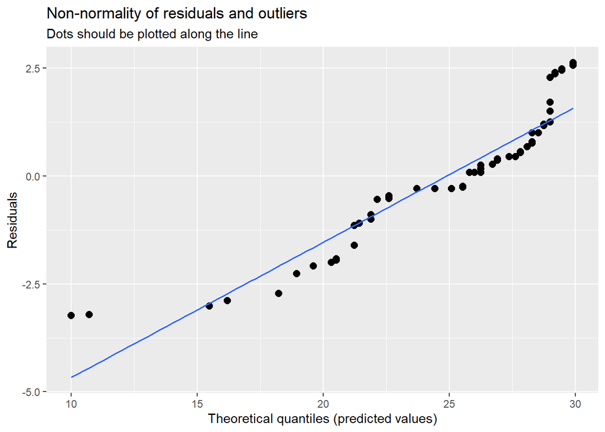

```
##
## [[2]]
## [[2]]$subjectId
```

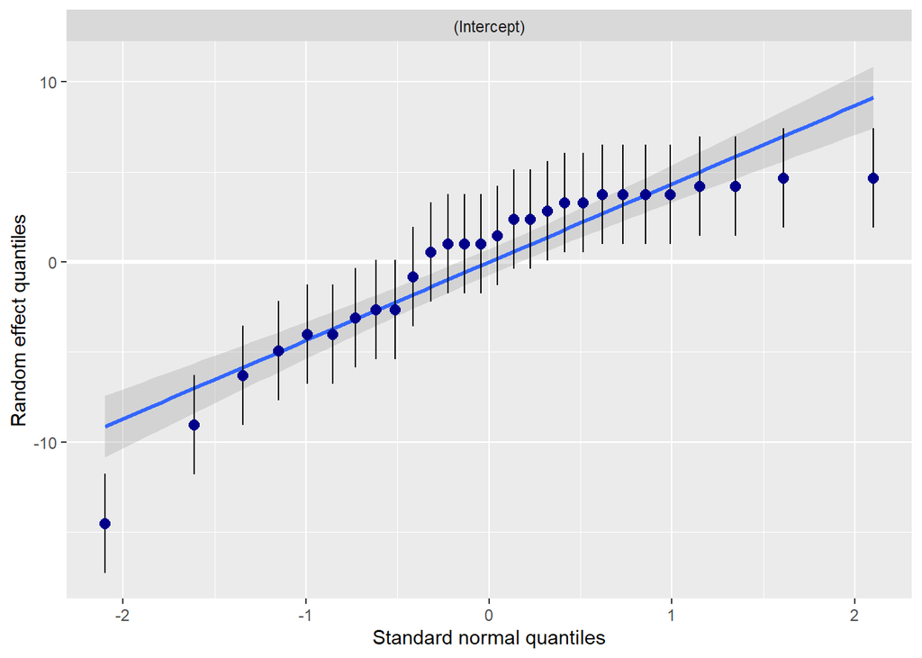

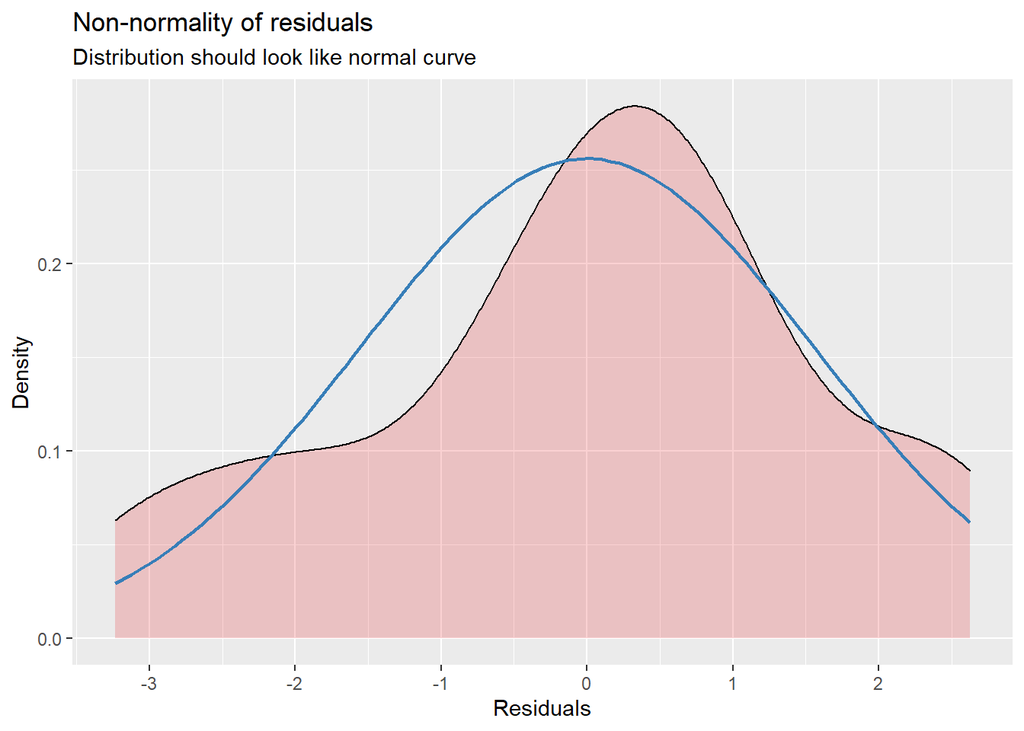

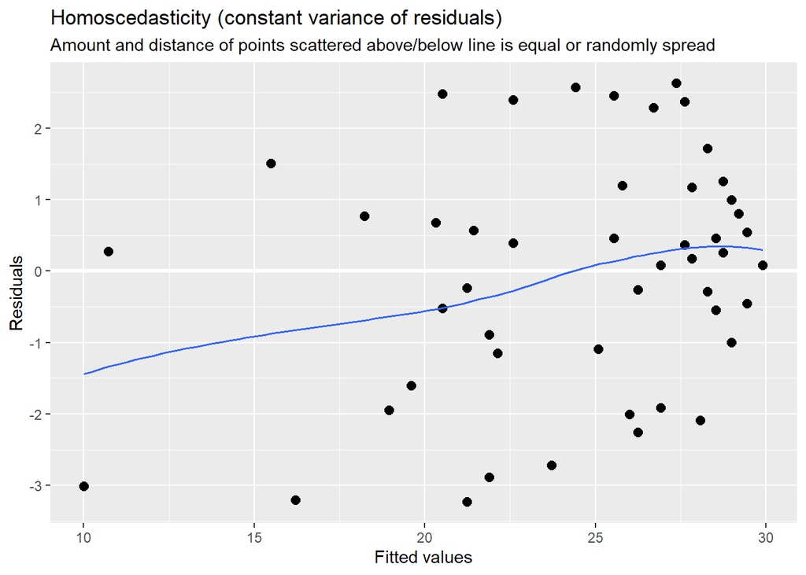

```r
plot_model(a1_m_1,type = "diag")
```

```r
## balancen kanssa
a1_m_1_test <- lmer(Score ~ Task + Balance +(1 | subjectId), data=data.30, REML = FALSE)
summ(a1_m_1_test)
```

```
## MODEL INFO:
## Observations: 56
## Dependent Variable: Score
## Type: Mixed effects linear regression
##
## MODEL FIT:
## AIC = 319.91, BIC = 330.03
## Pseudo-R² (fixed effects) = 0.01
## Pseudo-R² (total) = 0.84
##
## FIXED EFFECTS:
## ----------------------------------------------------------
##                        Est.   S.E.   t val.    d.f.      p
## ------------------- ------- ------ -------- ------- ------
## (Intercept)           25.43   1.03    24.78   36.65   0.00
## Taskscore_1           -0.69   0.56    -1.23   28.00   0.23
## Balancesecond         -0.38   0.56    -0.68   28.00   0.50
## ----------------------------------------------------------
##
## p values calculated using Satterthwaite d.f.
##
## RANDOM EFFECTS:
## -------------------------------------
##    Group      Parameter    Std. Dev.
## ----------- ------------- -----------
##  subjectId   (Intercept)     4.83
##  Residual                    2.08
## -------------------------------------
##
## Grouping variables:
## -----------------------------
##    Group     # groups   ICC
## ----------- ---------- ------
##  subjectId      28      0.84
## -----------------------------
```

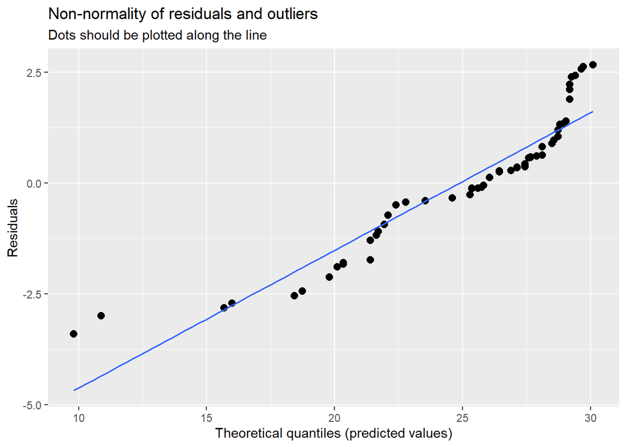

```
##
## [[2]]
## [[2]]$subjectId
```

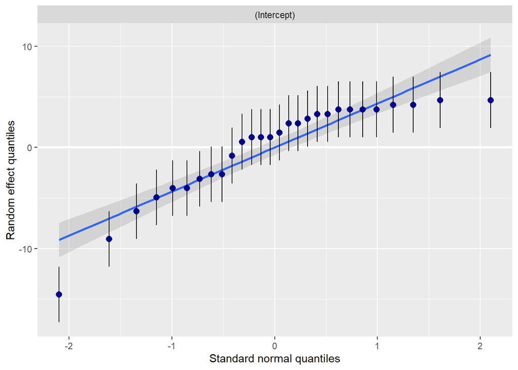

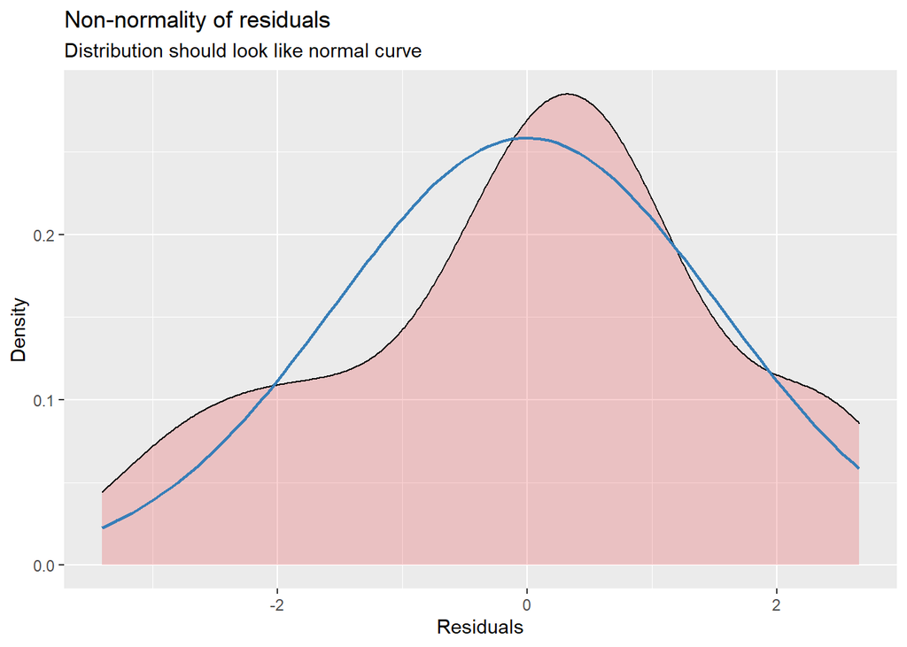

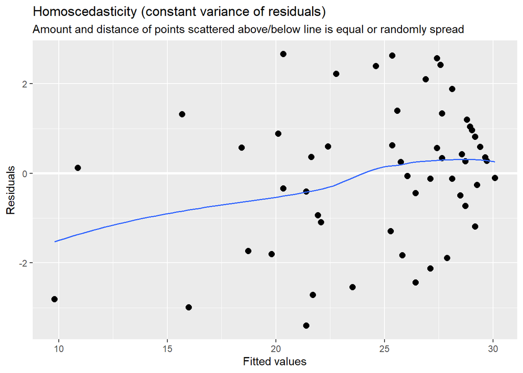

```r
plot_model(a1_m_1_test,type = "diag",grid = TRUE )
```

[figure not shown]

```r
plot_model(a1_m_1, type = "std", title = "Mallin kiinteiden efektien efektien koot [std]", axis.title = 'Efektin koko', axis.labels = c('Tehtävän suoritus toisena', 'Puhelin edessä'), show.values = TRUE)
```

#### 3.2.0.1 A2

```r
a2_m_1 <- lmer(Score ~ Task + (1 | subjectId), data=data.ei_30, REML = FALSE)
summ(a2_m_1)
```

```
## MODEL INFO:
## Observations: 36
## Dependent Variable: Score
## Type: Mixed effects linear regression
##
## MODEL FIT:
## AIC = 209.90, BIC = 216.23
## Pseudo-R² (fixed effects) = 0.01
## Pseudo-R² (total) = 0.81
##
## FIXED EFFECTS:
## --------------------------------------------------------
##                      Est.   S.E.   t val.    d.f.      p
## ----------------- ------- ------ -------- ------- ------
## (Intercept)         23.00   1.22    18.79   21.83   0.00
## Taskscore_1         -0.83   0.76    -1.09   18.00   0.29
## --------------------------------------------------------
##
## p values calculated using Satterthwaite d.f.
##
## RANDOM EFFECTS:
## -------------------------------------
##    Group      Parameter    Std. Dev.
## ----------- ------------- -----------
##  subjectId   (Intercept)     4.66
##  Residual                    2.29
## -------------------------------------
##
## Grouping variables:
## -----------------------------
##    Group     # groups   ICC
## ----------- ---------- ------
##  subjectId      18      0.81
## -----------------------------
```

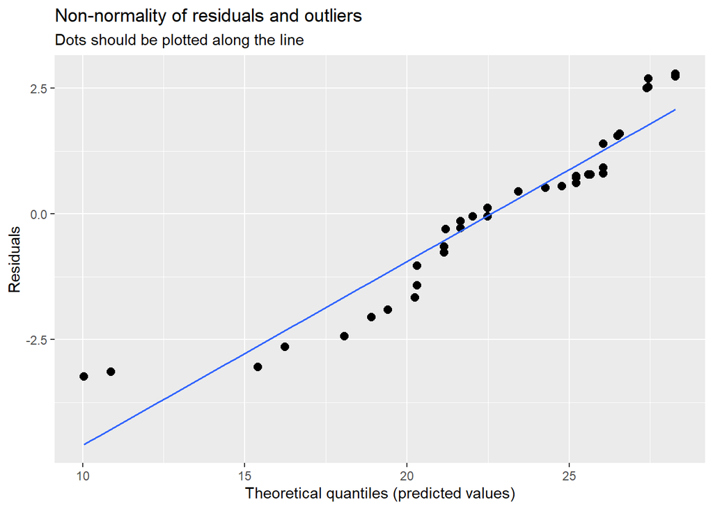

```
##
## [[2]]
## [[2]]$subjectId
```

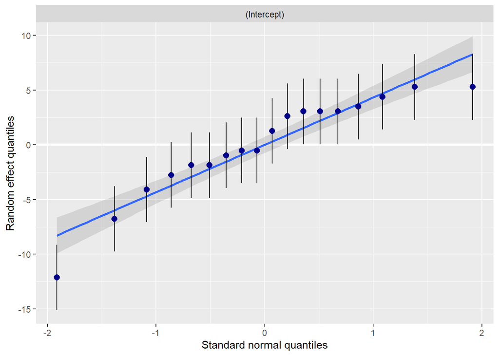

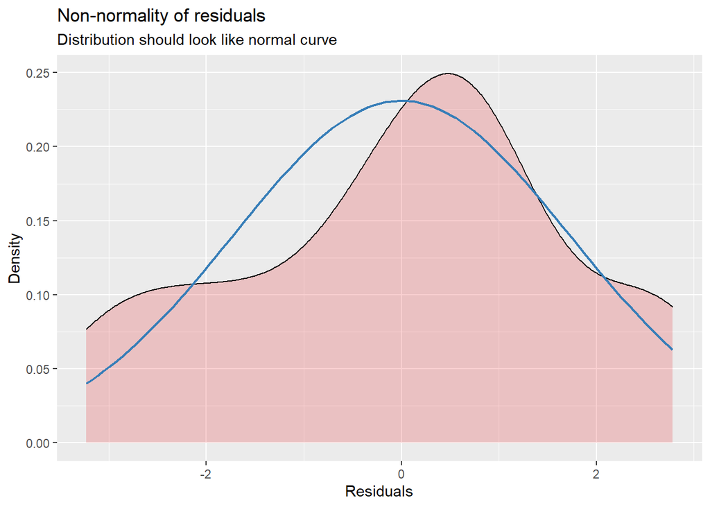

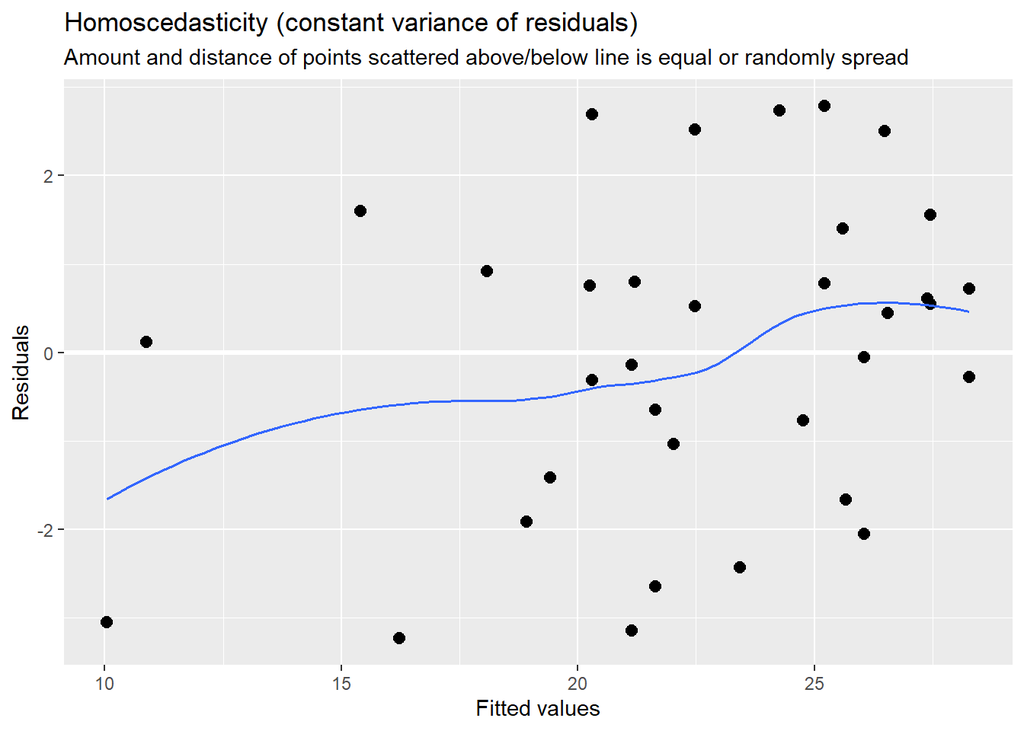

```r
plot_model(a2_m_1,type = "diag",grid = TRUE )
```

```r
a2_m_1_test <- lmer(Score ~ Task + Balance +(1 | subjectId), data=data.ei_30, REML = FALSE)
summ(a2_m_1_test)
```

```
## MODEL INFO:
## Observations: 36
## Dependent Variable: Score
## Type: Mixed effects linear regression
##
## MODEL FIT:
## AIC = 211.42, BIC = 219.34
## Pseudo-R² (fixed effects) = 0.01
## Pseudo-R² (total) = 0.81
##
## FIXED EFFECTS:
## ----------------------------------------------------------
##                        Est.   S.E.   t val.    d.f.      p
## ------------------- ------- ------ -------- ------- ------
## (Intercept)           23.23   1.27    18.33   24.56   0.00
## Taskscore_1           -0.77   0.76    -1.02   18.00   0.32
## Balancesecond         -0.52   0.76    -0.69   18.00   0.50
## ----------------------------------------------------------
##
## p values calculated using Satterthwaite d.f.
##
## RANDOM EFFECTS:
## -------------------------------------
##    Group      Parameter    Std. Dev.
## ----------- ------------- -----------
##  subjectId   (Intercept)     4.67
##  Residual                    2.26
## -------------------------------------
##
## Grouping variables:
## -----------------------------
##    Group     # groups   ICC
## ----------- ---------- ------
##  subjectId      18      0.81
## -----------------------------
```

[figure not shown]

```r
plot_model(a2_m_1, type = "std", title = "Mallin kiinteiden efektien efektien koot [std]", axis.title = 'Efektin koko', axis.labels = c('Tehtävän suoritus toisena', 'Puhelin edessä'), show.values = TRUE)
```

### 3.2.1 ASQ

#### 3.2.1.1 A1

##### 3.2.1.1.1 ASQint

```r
a1_m_asq_int <- lmer(Score ~ Task +  asq_int_c + (1 | subjectId), data=data.30, REML = FALSE)
a1_m_asq_intz <- lmer(Score ~ Task +  asq_int_z + (1 | subjectId), data=data.30, REML = FALSE)

a1_m_asq_int_iz <- lmer(Score ~ Task*asq_int_z + (1 | subjectId), data=data.30, REML = FALSE)

summ(a1_m_asq_int_iz)
```

```
## MODEL INFO:
## Observations: 56
## Dependent Variable: Score
## Type: Mixed effects linear regression
##
## MODEL FIT:
## AIC = 322.15, BIC = 334.30
## Pseudo-R² (fixed effects) = 0.01
## Pseudo-R² (total) = 0.84
##
## FIXED EFFECTS:
## ------------------------------------------------------------------
##                                Est.   S.E.   t val.    d.f.      p
## --------------------------- ------- ------ -------- ------- ------
## (Intercept)                   25.25   0.99    25.46   32.79   0.00
## Taskscore_1                   -0.71   0.56    -1.28   28.00   0.21
## asq_int_z                      0.82   2.00     0.41   32.79   0.68
## Taskscore_1:asq_int_z         -0.38   1.13    -0.34   28.00   0.74
## ------------------------------------------------------------------
##
## p values calculated using Satterthwaite d.f.
##
## RANDOM EFFECTS:
## -------------------------------------
##    Group      Parameter    Std. Dev.
## ----------- ------------- -----------
##  subjectId   (Intercept)     4.81
##  Residual                    2.09
## -------------------------------------
##
## Grouping variables:
## -----------------------------
##    Group     # groups   ICC
## ----------- ---------- ------
##  subjectId      28      0.84
## -----------------------------
```

##### 3.2.1.1.2 ASQext

```r
a1_m_asq_ext <- lmer(Score ~ Task +  asq_ext_c + (1 | subjectId), data=data.30, REML = FALSE)
a1_m_asq_extz <- lmer(Score ~ Task + asq_ext_z + (1 | subjectId), data=data.30, REML = FALSE)

a1_m_asq_ext_iz <- lmer(Score ~ Task*asq_ext_z + (1 | subjectId), data=data.30, REML = FALSE)

summ(a1_m_asq_ext_iz)
```

```
## MODEL INFO:
## Observations: 56
## Dependent Variable: Score
## Type: Mixed effects linear regression
##
## MODEL FIT:
## AIC = 319.06, BIC = 331.21
## Pseudo-R² (fixed effects) = 0.03
## Pseudo-R² (total) = 0.86
##
## FIXED EFFECTS:
## ------------------------------------------------------------------
##                                Est.   S.E.   t val.    d.f.      p
## --------------------------- ------- ------ -------- ------- ------
## (Intercept)                   25.25   0.98    25.68   32.39   0.00
## Taskscore_1                   -0.71   0.53    -1.34   28.00   0.19
## asq_ext_z                      2.16   1.98     1.09   32.39   0.29
## Taskscore_1:asq_ext_z         -1.88   1.07    -1.75   28.00   0.09
## ------------------------------------------------------------------
##
## p values calculated using Satterthwaite d.f.
##
## RANDOM EFFECTS:
## -------------------------------------
##    Group      Parameter    Std. Dev.
## ----------- ------------- -----------
##  subjectId   (Intercept)     4.81
##  Residual                    1.99
## -------------------------------------
##
## Grouping variables:
## -----------------------------
##    Group     # groups   ICC
## ----------- ---------- ------
##  subjectId      28      0.85
## -----------------------------
```

```r
summ(a1_m_asq_extz)
```

```
## MODEL INFO:
## Observations: 56
## Dependent Variable: Score
## Type: Mixed effects linear regression
##
## MODEL FIT:
## AIC = 319.96, BIC = 330.09
## Pseudo-R² (fixed effects) = 0.02
## Pseudo-R² (total) = 0.84
##
## FIXED EFFECTS:
## --------------------------------------------------------
##                      Est.   S.E.   t val.    d.f.      p
## ----------------- ------- ------ -------- ------- ------
## (Intercept)         25.25   0.99    25.58   32.86   0.00
## Taskscore_1         -0.71   0.56    -1.28   28.00   0.21
## asq_ext_z            1.22   1.91     0.64   28.00   0.53
## --------------------------------------------------------
##
## p values calculated using Satterthwaite d.f.
##
## RANDOM EFFECTS:
## -------------------------------------
##    Group      Parameter    Std. Dev.
## ----------- ------------- -----------
##  subjectId   (Intercept)     4.78
##  Residual                    2.09
## -------------------------------------
##
## Grouping variables:
## -----------------------------
##    Group     # groups   ICC
## ----------- ---------- ------
##  subjectId      28      0.84
## -----------------------------
```

##### 3.2.1.1.3 ASQ full

```r
a1_m_asq <- lmer(Score ~ Task + asq_c + (1 | subjectId), data=data.30, REML = FALSE)
a1_m_asqz <- lmer(Score ~ Task + asq_z + (1 | subjectId), data=data.30, REML = FALSE)

a1_m_asq_iz <- lmer(Score ~ Task*asq_z + (1 | subjectId), data=data.30, REML = FALSE)

summ(a1_m_asq)
```

```
## MODEL INFO:
## Observations: 56
## Dependent Variable: Score
## Type: Mixed effects linear regression
##
## MODEL FIT:
## AIC = 320.00, BIC = 330.12
## Pseudo-R² (fixed effects) = 0.02
## Pseudo-R² (total) = 0.84
##
## FIXED EFFECTS:
## --------------------------------------------------------
##                      Est.   S.E.   t val.    d.f.      p
## ----------------- ------- ------ -------- ------- ------
## (Intercept)         25.25   0.99    25.57   32.85   0.00
## Taskscore_1         -0.71   0.56    -1.28   28.00   0.21
## asq_c                0.83   1.36     0.61   28.00   0.55
## --------------------------------------------------------
##
## p values calculated using Satterthwaite d.f.
##
## RANDOM EFFECTS:
## -------------------------------------
##    Group      Parameter    Std. Dev.
## ----------- ------------- -----------
##  subjectId   (Intercept)     4.79
##  Residual                    2.09
## -------------------------------------
##
## Grouping variables:
## -----------------------------
##    Group     # groups   ICC
## ----------- ---------- ------
##  subjectId      28      0.84
## -----------------------------
```

#### 3.2.1.2 A2

##### 3.2.1.2.1 ASQint

```r
a2_m_asq_int <- lmer(Score ~ Task +  asq_int_c + (1 | subjectId), data=data.ei_30, REML = FALSE)
a2_m_asq_intz <- lmer(Score ~ Task +  asq_int_z + (1 | subjectId), data=data.ei_30, REML = FALSE)

a2_m_asq_int_iz <- lmer(Score ~ Task*asq_int_z + (1 | subjectId), data=data.ei_30, REML = FALSE)

summ(a2_m_asq_int)
```

```
## MODEL INFO:
## Observations: 36
## Dependent Variable: Score
## Type: Mixed effects linear regression
##
## MODEL FIT:
## AIC = 211.80, BIC = 219.71
## Pseudo-R² (fixed effects) = 0.01
## Pseudo-R² (total) = 0.81
##
## FIXED EFFECTS:
## --------------------------------------------------------
##                      Est.   S.E.   t val.    d.f.      p
## ----------------- ------- ------ -------- ------- ------
## (Intercept)         23.00   1.22    18.84   21.85   0.00
## Taskscore_1         -0.83   0.76    -1.09   18.00   0.29
## asq_int_c            0.43   1.34     0.32   18.00   0.75
## --------------------------------------------------------
##
## p values calculated using Satterthwaite d.f.
##
## RANDOM EFFECTS:
## -------------------------------------
##    Group      Parameter    Std. Dev.
## ----------- ------------- -----------
##  subjectId   (Intercept)     4.65
##  Residual                    2.29
## -------------------------------------
##
## Grouping variables:
## -----------------------------
##    Group     # groups   ICC
## ----------- ---------- ------
##  subjectId      18      0.80
## -----------------------------
```

##### 3.2.1.2.2 ASQext

```r
a2_m_asq_ext <- lmer(Score ~ Task +  asq_ext_c + (1 | subjectId), data=data.ei_30, REML = FALSE)
a2_m_asq_extz <- lmer(Score ~ Task +  asq_ext_z + (1 | subjectId), data=data.ei_30, REML = FALSE)

a2_m_asq_ext_iz <- lmer(Score ~ Task*asq_ext_z + (1 | subjectId), data=data.ei_30, REML = FALSE)

summ(a2_m_asq_ext_iz)
```

```
## MODEL INFO:
## Observations: 36
## Dependent Variable: Score
## Type: Mixed effects linear regression
##
## MODEL FIT:
## AIC = 210.35, BIC = 219.85
## Pseudo-R² (fixed effects) = 0.02
## Pseudo-R² (total) = 0.84
##
## FIXED EFFECTS:
## ------------------------------------------------------------------
##                                Est.   S.E.   t val.    d.f.      p
## --------------------------- ------- ------ -------- ------- ------
## (Intercept)                   23.00   1.21    18.97   21.16   0.00
## Taskscore_1                   -0.83   0.69    -1.21   18.00   0.24
## asq_ext_z                      1.12   2.46     0.46   21.16   0.65
## Taskscore_1:asq_ext_z         -2.77   1.40    -1.98   18.00   0.06
## ------------------------------------------------------------------
##
## p values calculated using Satterthwaite d.f.
##
## RANDOM EFFECTS:
## -------------------------------------
##    Group      Parameter    Std. Dev.
## ----------- ------------- -----------
##  subjectId   (Intercept)     4.71
##  Residual                    2.07
## -------------------------------------
##
## Grouping variables:
## -----------------------------
##    Group     # groups   ICC
## ----------- ---------- ------
##  subjectId      18      0.84
## -----------------------------
```

##### 3.2.1.2.3 ASQ full

```r
a2_m_asq <- lmer(Score ~ Task + asq_c + (1 | subjectId), data=data.ei_30, REML = FALSE)
a2_m_asqz <- lmer(Score ~ Task + asq_z + (1 | subjectId), data=data.ei_30, REML = FALSE)

a2_m_asq_iz <- lmer(Score ~ Task*asq_z + (1 | subjectId), data=data.ei_30, REML = FALSE)

summ(a2_m_asq)
```

```
## MODEL INFO:
## Observations: 36
## Dependent Variable: Score
## Type: Mixed effects linear regression
##
## MODEL FIT:
## AIC = 211.87, BIC = 219.79
## Pseudo-R² (fixed effects) = 0.01
## Pseudo-R² (total) = 0.81
##
## FIXED EFFECTS:
## --------------------------------------------------------
##                      Est.   S.E.   t val.    d.f.      p
## ----------------- ------- ------ -------- ------- ------
## (Intercept)         23.00   1.22    18.81   21.83   0.00
## Taskscore_1         -0.83   0.76    -1.09   18.00   0.29
## asq_c                0.24   1.48     0.16   18.00   0.87
## --------------------------------------------------------
##
## p values calculated using Satterthwaite d.f.
##
## RANDOM EFFECTS:
## -------------------------------------
##    Group      Parameter    Std. Dev.
## ----------- ------------- -----------
##  subjectId   (Intercept)     4.66
##  Residual                    2.29
## -------------------------------------
##
## Grouping variables:
## -----------------------------
##    Group     # groups   ICC
## ----------- ---------- ------
##  subjectId      18      0.81
## -----------------------------
```

### 3.2.2 OVS

#### 3.2.2.1 A1

#### 3.2.2.2 OVS Full

```r
a1_m_ovs <- lmer(Score ~ Task + ovs_c + (1 | subjectId), data=data.30, REML = FALSE)
a1_m_ovsz <- lmer(Score ~Task + ovs_z + (1 | subjectId), data=data.30, REML = FALSE)

a1_m_ovs_iz <- lmer(Score ~Task*ovs_z + (1 | subjectId), data=data.30, REML = FALSE)

summ(a1_m_ovs)
```

```
## MODEL INFO:
## Observations: 56
## Dependent Variable: Score
## Type: Mixed effects linear regression
##
## MODEL FIT:
## AIC = 319.25, BIC = 329.38
## Pseudo-R² (fixed effects) = 0.04
## Pseudo-R² (total) = 0.84
##
## FIXED EFFECTS:
## --------------------------------------------------------
##                      Est.   S.E.   t val.    d.f.      p
## ----------------- ------- ------ -------- ------- ------
## (Intercept)         25.25   0.98    25.88   32.98   0.00
## Taskscore_1         -0.71   0.56    -1.28   28.00   0.21
## ovs_c                1.55   1.46     1.07   28.00   0.30
## --------------------------------------------------------
##
## p values calculated using Satterthwaite d.f.
##
## RANDOM EFFECTS:
## -------------------------------------
##    Group      Parameter    Std. Dev.
## ----------- ------------- -----------
##  subjectId   (Intercept)     4.72
##  Residual                    2.09
## -------------------------------------
##
## Grouping variables:
## -----------------------------
##    Group     # groups   ICC
## ----------- ---------- ------
##  subjectId      28      0.84
## -----------------------------
```

#### 3.2.2.3 OVS Salience

```r
a1_m_ovs_sal <- lmer(Score ~ Task + ovs_salience_c + (1 | subjectId), data=data.30, REML = FALSE)
a1_m_ovs_salz <- lmer(Score ~ Task +  ovs_salience_z + (1 | subjectId), data=data.30, REML = FALSE)

a1_m_ovs_sal_iz <- lmer(Score ~ Task*ovs_salience_z + (1 | subjectId), data=data.30, REML = FALSE)

summ(a1_m_ovs_sal)
```

```
## MODEL INFO:
## Observations: 56
## Dependent Variable: Score
## Type: Mixed effects linear regression
##
## MODEL FIT:
## AIC = 319.85, BIC = 329.98
## Pseudo-R² (fixed effects) = 0.02
## Pseudo-R² (total) = 0.84
##
## FIXED EFFECTS:
## -----------------------------------------------------------
##                         Est.   S.E.   t val.    d.f.      p
## -------------------- ------- ------ -------- ------- ------
## (Intercept)            25.25   0.99    25.63   32.88   0.00
## Taskscore_1            -0.71   0.56    -1.28   28.00   0.21
## ovs_salience_c         -0.85   1.19    -0.72   28.00   0.48
## -----------------------------------------------------------
##
## p values calculated using Satterthwaite d.f.
##
## RANDOM EFFECTS:
## -------------------------------------
##    Group      Parameter    Std. Dev.
## ----------- ------------- -----------
##  subjectId   (Intercept)     4.77
##  Residual                    2.09
## -------------------------------------
##
## Grouping variables:
## -----------------------------
##    Group     # groups   ICC
## ----------- ---------- ------
##  subjectId      28      0.84
## -----------------------------
```

#### 3.2.2.4 OVS Reactibility

```r
a1_m_ovs_rec <- lmer(Score ~ Task + ovs_reactibility_c + (1 | subjectId), data=data.30, REML = FALSE)
a1_m_ovs_recz <- lmer(Score ~ Task + ovs_reactibility_z + (1 | subjectId), data=data.30, REML = FALSE)

a1_m_ovs_rec_iz <- lmer(Score ~Task*ovs_reactibility_z + (1 | subjectId), data=data.30, REML = FALSE)

summ(a1_m_ovs_rec)
```

```
## MODEL INFO:
## Observations: 56
## Dependent Variable: Score
## Type: Mixed effects linear regression
##
## MODEL FIT:
## AIC = 318.38, BIC = 328.50
## Pseudo-R² (fixed effects) = 0.07
## Pseudo-R² (total) = 0.84
##
## FIXED EFFECTS:
## ---------------------------------------------------------------
##                             Est.   S.E.   t val.    d.f.      p
## ------------------------ ------- ------ -------- ------- ------
## (Intercept)                25.25   0.96    26.25   33.14   0.00
## Taskscore_1                -0.71   0.56    -1.28   28.00   0.21
## ovs_reactibility_c          1.71   1.19     1.44   28.00   0.16
## ---------------------------------------------------------------
##
## p values calculated using Satterthwaite d.f.
##
## RANDOM EFFECTS:
## -------------------------------------
##    Group      Parameter    Std. Dev.
## ----------- ------------- -----------
##  subjectId   (Intercept)     4.64
##  Residual                    2.09
## -------------------------------------
##
## Grouping variables:
## -----------------------------
##    Group     # groups   ICC
## ----------- ---------- ------
##  subjectId      28      0.83
## -----------------------------
```

#### 3.2.2.5 OVS Monitoring

```r
a1_m_ovs_mon <- lmer(Score ~ Task +  ovs_monitoring_c + (1 | subjectId), data=data.30, REML = FALSE)
a1_m_ovs_monz <- lmer(Score ~Task +  ovs_monitoring_z + (1 | subjectId), data=data.30, REML = FALSE)

a1_m_ovs_mon_iz <- lmer(Score ~ Task*ovs_monitoring_z + (1 | subjectId), data=data.30, REML = FALSE)

summ(a1_m_ovs_mon)
```

```
## MODEL INFO:
## Observations: 56
## Dependent Variable: Score
## Type: Mixed effects linear regression
##
## MODEL FIT:
## AIC = 317.79, BIC = 327.92
## Pseudo-R² (fixed effects) = 0.09
## Pseudo-R² (total) = 0.84
##
## FIXED EFFECTS:
## -------------------------------------------------------------
##                           Est.   S.E.   t val.    d.f.      p
## ---------------------- ------- ------ -------- ------- ------
## (Intercept)              25.25   0.95    26.51   33.25   0.00
## Taskscore_1              -0.71   0.56    -1.28   28.00   0.21
## ovs_monitoring_c          1.66   1.01     1.64   28.00   0.11
## -------------------------------------------------------------
##
## p values calculated using Satterthwaite d.f.
##
## RANDOM EFFECTS:
## -------------------------------------
##    Group      Parameter    Std. Dev.
## ----------- ------------- -----------
##  subjectId   (Intercept)     4.58
##  Residual                    2.09
## -------------------------------------
##
## Grouping variables:
## -----------------------------
##    Group     # groups   ICC
## ----------- ---------- ------
##  subjectId      28      0.83
## -----------------------------
```

#### 3.2.2.6 A2

#### 3.2.2.7 OVS Full

```r
a2_m_ovs <- lmer(Score ~ Task + ovs_c + (1 | subjectId), data=data.ei_30, REML = FALSE)
a2_m_ovsz <- lmer(Score ~ Task + ovs_z + (1 | subjectId), data=data.ei_30, REML = FALSE)

a2_m_ovs_iz <- lmer(Score ~ Task*ovs_z + (1 | subjectId), data=data.ei_30, REML = FALSE)

summ(a2_m_ovs)
```

```
## MODEL INFO:
## Observations: 36
## Dependent Variable: Score
## Type: Mixed effects linear regression
##
## MODEL FIT:
## AIC = 211.51, BIC = 219.43
## Pseudo-R² (fixed effects) = 0.03
## Pseudo-R² (total) = 0.81
##
## FIXED EFFECTS:
## --------------------------------------------------------
##                      Est.   S.E.   t val.    d.f.      p
## ----------------- ------- ------ -------- ------- ------
## (Intercept)         23.00   1.21    18.98   21.91   0.00
## Taskscore_1         -0.83   0.76    -1.09   18.00   0.29
## ovs_c                1.06   1.69     0.63   18.00   0.54
## --------------------------------------------------------
##
## p values calculated using Satterthwaite d.f.
##
## RANDOM EFFECTS:
## -------------------------------------
##    Group      Parameter    Std. Dev.
## ----------- ------------- -----------
##  subjectId   (Intercept)     4.60
##  Residual                    2.29
## -------------------------------------
##
## Grouping variables:
## -----------------------------
##    Group     # groups   ICC
## ----------- ---------- ------
##  subjectId      18      0.80
## -----------------------------
```

#### 3.2.2.8 OVS Salience

```r
a2_m_ovs_sal <- lmer(Score ~ Task +  ovs_salience_c + (1 | subjectId), data=data.ei_30, REML = FALSE)
a2_m_ovs_salz <- lmer(Score ~ Task +  ovs_salience_z + (1 | subjectId), data=data.ei_30, REML = FALSE)

a2_m_ovs_sal_iz <- lmer(Score ~ Task*ovs_salience_z + (1 | subjectId), data=data.ei_30, REML = FALSE)

summ(a2_m_ovs_sal)
```

```
## MODEL INFO:
## Observations: 36
## Dependent Variable: Score
## Type: Mixed effects linear regression
##
## MODEL FIT:
## AIC = 211.89, BIC = 219.81
## Pseudo-R² (fixed effects) = 0.01
## Pseudo-R² (total) = 0.81
##
## FIXED EFFECTS:
## -----------------------------------------------------------
##                         Est.   S.E.   t val.    d.f.      p
## -------------------- ------- ------ -------- ------- ------
## (Intercept)            23.00   1.22    18.80   21.83   0.00
## Taskscore_1            -0.83   0.76    -1.09   18.00   0.29
## ovs_salience_c         -0.12   1.44    -0.08   18.00   0.94
## -----------------------------------------------------------
##
## p values calculated using Satterthwaite d.f.
##
## RANDOM EFFECTS:
## -------------------------------------
##    Group      Parameter    Std. Dev.
## ----------- ------------- -----------
##  subjectId   (Intercept)     4.66
##  Residual                    2.29
## -------------------------------------
##
## Grouping variables:
## -----------------------------
##    Group     # groups   ICC
## ----------- ---------- ------
##  subjectId      18      0.81
## -----------------------------
```

#### 3.2.2.9 OVS Reactibility

```r
a2_m_ovs_rec <- lmer(Score ~ Task + ovs_reactibility_c + (1 | subjectId), data=data.ei_30, REML = FALSE)
a2_m_ovs_recz <- lmer(Score ~ Task + ovs_reactibility_z + (1 | subjectId), data=data.ei_30, REML = FALSE)

a2_m_ovs_rec_iz <- lmer(Score ~ Task*ovs_reactibility_z + (1 | subjectId), data=data.ei_30, REML = FALSE)

summ(a2_m_ovs_rec)
```

```
## MODEL INFO:
## Observations: 36
## Dependent Variable: Score
## Type: Mixed effects linear regression
##
## MODEL FIT:
## AIC = 211.81, BIC = 219.73
## Pseudo-R² (fixed effects) = 0.01
## Pseudo-R² (total) = 0.81
##
## FIXED EFFECTS:
## ---------------------------------------------------------------
##                             Est.   S.E.   t val.    d.f.      p
## ------------------------ ------- ------ -------- ------- ------
## (Intercept)                23.00   1.22    18.84   21.85   0.00
## Taskscore_1                -0.83   0.76    -1.09   18.00   0.29
## ovs_reactibility_c          0.43   1.41     0.30   18.00   0.77
## ---------------------------------------------------------------
##
## p values calculated using Satterthwaite d.f.
##
## RANDOM EFFECTS:
## -------------------------------------
##    Group      Parameter    Std. Dev.
## ----------- ------------- -----------
##  subjectId   (Intercept)     4.65
##  Residual                    2.29
## -------------------------------------
##
## Grouping variables:
## -----------------------------
##    Group     # groups   ICC
## ----------- ---------- ------
##  subjectId      18      0.80
## -----------------------------
```

#### 3.2.2.10 OVS Monitoring

```r
a2_m_ovs_mon <- lmer(Score ~ Task +  ovs_monitoring_c + (1 | subjectId), data=data.ei_30, REML = FALSE)
a2_m_ovs_monz <- lmer(Score ~ Task +  ovs_monitoring_z + (1 | subjectId), data=data.ei_30, REML = FALSE)

a2_m_ovs_mon_iz <- lmer(Score ~ Task*ovs_monitoring_z + (1 | subjectId), data=data.ei_30, REML = FALSE)

summ(a2_m_ovs_mon)
```

```
## MODEL INFO:
## Observations: 36
## Dependent Variable: Score
## Type: Mixed effects linear regression
##
## MODEL FIT:
## AIC = 210.33, BIC = 218.25
## Pseudo-R² (fixed effects) = 0.08
## Pseudo-R² (total) = 0.81
##
## FIXED EFFECTS:
## -------------------------------------------------------------
##                           Est.   S.E.   t val.    d.f.      p
## ---------------------- ------- ------ -------- ------- ------
## (Intercept)              23.00   1.18    19.54   22.17   0.00
## Taskscore_1              -0.83   0.76    -1.09   18.00   0.29
## ovs_monitoring_c          1.59   1.24     1.28   18.00   0.22
## -------------------------------------------------------------
##
## p values calculated using Satterthwaite d.f.
##
## RANDOM EFFECTS:
## -------------------------------------
##    Group      Parameter    Std. Dev.
## ----------- ------------- -----------
##  subjectId   (Intercept)     4.44
##  Residual                    2.29
## -------------------------------------
##
## Grouping variables:
## -----------------------------
##    Group     # groups   ICC
## ----------- ---------- ------
##  subjectId      18      0.79
## -----------------------------
```

### 3.2.3 VDAQ

#### 3.2.3.1 A1

```r
a1_m_vdaq <- lmer(Score ~ Task +vdaq_c + (1 | subjectId), data=data.30, REML = FALSE)
a1_m_vdaqz <- lmer(Score ~ Task + vdaq_z + (1 | subjectId), data=data.30, REML = FALSE)

a1_m_vdaq_i <- lmer(Score ~ Task*vdaq_c + (1 | subjectId), data=data.30, REML = FALSE)
a1_m_vdaq_iz <- lmer(Score ~ Task*vdaq_z + (1 | subjectId), data=data.30, REML = FALSE)


summ(a1_m_vdaq)
```

```
## MODEL INFO:
## Observations: 56
## Dependent Variable: Score
## Type: Mixed effects linear regression
##
## MODEL FIT:
## AIC = 318.68, BIC = 328.81
## Pseudo-R² (fixed effects) = 0.06
## Pseudo-R² (total) = 0.84
##
## FIXED EFFECTS:
## --------------------------------------------------------
##                      Est.   S.E.   t val.    d.f.      p
## ----------------- ------- ------ -------- ------- ------
## (Intercept)         25.25   0.97    26.12   33.08   0.00
## Taskscore_1         -0.71   0.56    -1.28   28.00   0.21
## vdaq_c               4.31   3.27     1.32   28.00   0.20
## --------------------------------------------------------
##
## p values calculated using Satterthwaite d.f.
##
## RANDOM EFFECTS:
## -------------------------------------
##    Group      Parameter    Std. Dev.
## ----------- ------------- -----------
##  subjectId   (Intercept)     4.67
##  Residual                    2.09
## -------------------------------------
##
## Grouping variables:
## -----------------------------
##    Group     # groups   ICC
## ----------- ---------- ------
##  subjectId      28      0.83
## -----------------------------
```

#### 3.2.3.2 A2

```r
a2_m_vdaq <- lmer(Score ~ Task + vdaq_c + (1 | subjectId), data=data.ei_30, REML = FALSE)
a2_m_vdaqz <- lmer(Score ~ Task + vdaq_z + (1 | subjectId), data=data.ei_30, REML = FALSE)
a2_m_vdaq_i <- lmer(Score ~ Task*vdaq_c + (1 | subjectId), data=data.ei_30, REML = FALSE)
a2_m_vdaq_iz <- lmer(Score ~ Task*vdaq_z + (1 | subjectId), data=data.ei_30, REML = FALSE)


summ(a2_m_vdaq_iz)
```

```
## MODEL INFO:
## Observations: 36
## Dependent Variable: Score
## Type: Mixed effects linear regression
##
## MODEL FIT:
## AIC = 209.90, BIC = 219.41
## Pseudo-R² (fixed effects) = 0.05
## Pseudo-R² (total) = 0.84
##
## FIXED EFFECTS:
## ---------------------------------------------------------------
##                             Est.   S.E.   t val.    d.f.      p
## ------------------------ ------- ------ -------- ------- ------
## (Intercept)                23.00   1.20    19.20   21.25   0.00
## Taskscore_1                -0.83   0.69    -1.20   18.00   0.24
## vdaq_z                      3.04   2.43     1.25   21.25   0.22
## Taskscore_1:vdaq_z         -2.76   1.40    -1.96   18.00   0.07
## ---------------------------------------------------------------
##
## p values calculated using Satterthwaite d.f.
##
## RANDOM EFFECTS:
## -------------------------------------
##    Group      Parameter    Std. Dev.
## ----------- ------------- -----------
##  subjectId   (Intercept)     4.64
##  Residual                    2.08
## -------------------------------------
##
## Grouping variables:
## -----------------------------
##    Group     # groups   ICC
## ----------- ---------- ------
##  subjectId      18      0.83
## -----------------------------
```

# 4 Puhelin AICc-taulukko

Taulukot gradussa.

## 4.1 A1

AICC eri kuin muilla funktiolla-> korvaa

```r
tab_model(a1_model0,a1_m_1,a1_m_1_test, show.aicc = TRUE)
```

|  | Score |  |  | Score |  |  | Score |  |  |
| --- | --- | --- | --- | --- | --- | --- | --- | --- | --- |
| Predictors | Estimates | CI | p | Estimates | CI | p | Estimates | CI | p |
| (Intercept) | 24.89 | 22.98 – 26.81 | **<0.001** | 25.25 | 23.26 – 27.24 | **<0.001** | 25.43 | 23.37 – 27.49 | **<0.001** |
| Task [score_1] |  |  |  | -0.71 | -1.84 – 0.41 | 0.208 | -0.69 | -1.80 – 0.43 | 0.223 |
| Balance [second] |  |  |  |  |  |  | -0.38 | -1.50 – 0.74 | 0.499 |
| Random Effects |  |  |  |  |  |  |  |  |  |
| σ<sup>2</sup> | 4.64 |  |  | 4.39 |  |  | 4.32 |  |  |
| τ<sub>00</sub> | 23.13 <sub>subjectId</sub> |  |  | 23.26 <sub>subjectId</sub> |  |  | 23.29 <sub>subjectId</sub> |  |  |
| ICC | 0.83 |  |  | 0.84 |  |  | 0.84 |  |  |
| N | 28 <sub>subjectId</sub> |  |  | 28 <sub>subjectId</sub> |  |  | 28 <sub>subjectId</sub> |  |  |
| Observations | 56 |  |  | 56 |  |  | 56 |  |  |
| Marginal R<sup>2</sup> / Conditional R<sup>2</sup> | 0.000 / 0.833 |  |  | 0.005 / 0.842 |  |  | 0.006 / 0.845 |  |  |
| AICc | 316.660 |  |  | 316.695 |  |  | 317.955 |  |  |

```r
m_list <- c(a1_model0,a1_m_1,a1_m_1_test)
m_names <- c("null", "Task", "Task+Balance")
aictab(m_list,m_names, second.ord = TRUE)
```

```
## # A tibble: 3 × 8
##   Modnames         K  AICc Delta_AICc ModelLik AICcWt    LL Cum.Wt
##   <chr>        <dbl> <dbl>      <dbl>    <dbl>  <dbl> <dbl>  <dbl>
## 1 null             3  318.      0        1      0.513 -156.  0.513
## 2 Task             4  319.      0.740    0.691  0.354 -155.  0.867
## 3 Task+Balance     5  321.      2.70     0.260  0.133 -155.  1
```

## 4.2 A2

```r
tab_model(a2_model0,a2_m_1,a2_m_1_test, show.aicc = TRUE)
```

|  | Score |  |  | Score |  |  | Score |  |  |
| --- | --- | --- | --- | --- | --- | --- | --- | --- | --- |
| Predictors | Estimates | CI | p | Estimates | CI | p | Estimates | CI | p |
| (Intercept) | 22.58 | 20.22 – 24.95 | **<0.001** | 23.00 | 20.51 – 25.49 | **<0.001** | 23.23 | 20.65 – 25.82 | **<0.001** |
| Task [score_1] |  |  |  | -0.83 | -2.39 – 0.72 | 0.283 | -0.77 | -2.32 – 0.77 | 0.314 |
| Balance [second] |  |  |  |  |  |  | -0.52 | -2.07 – 1.02 | 0.493 |
| Random Effects |  |  |  |  |  |  |  |  |  |
| σ<sup>2</sup> | 5.58 |  |  | 5.24 |  |  | 5.10 |  |  |
| τ<sub>00</sub> | 21.55 <sub>subjectId</sub> |  |  | 21.72 <sub>subjectId</sub> |  |  | 21.79 <sub>subjectId</sub> |  |  |
| ICC | 0.79 |  |  | 0.81 |  |  | 0.81 |  |  |
| N | 18 <sub>subjectId</sub> |  |  | 18 <sub>subjectId</sub> |  |  | 18 <sub>subjectId</sub> |  |  |
| Observations | 36 |  |  | 36 |  |  | 36 |  |  |
| Marginal R<sup>2</sup> / Conditional R<sup>2</sup> | 0.000 / 0.794 |  |  | 0.007 / 0.807 |  |  | 0.009 / 0.812 |  |  |
| AICc | 207.651 |  |  | 207.697 |  |  | 208.604 |  |  |

```r
m_list <- c(a2_model0,a2_m_1,a2_m_1_test)
m_names <- c("null", "Task", "Task+Balance")
aictab(m_list,m_names, second.ord = TRUE)
```

```
## # A tibble: 3 × 8
##   Modnames         K  AICc Delta_AICc ModelLik AICcWt    LL Cum.Wt
##   <chr>        <dbl> <dbl>      <dbl>    <dbl>  <dbl> <dbl>  <dbl>
## 1 null             3  210.       0       1     0.601  -102.  0.601
## 2 Task             4  211.       1.38    0.500 0.301  -101.  0.902
## 3 Task+Balance     5  213.       3.62    0.164 0.0983 -101.  1
```

# 5 AOSpan, Yksilölliset erot AICc-taulukko

```r
l_models <- c(a1_model0,a1_m_1,a1_m_1_test, a1_m_asqz,a1_m_asq_intz,a1_m_asq_extz,a1_m_ovsz,a1_m_ovs_monz,a1_m_ovs_recz,a1_m_ovs_salz,a1_m_vdaqz,a1_m_asq_iz,a1_m_asq_int_iz,a1_m_asq_ext_iz,a1_m_ovs_iz,a1_m_ovs_mon_iz,a1_m_ovs_rec_iz,a1_m_ovs_sal_iz,a1_m_vdaq_iz)
l_names <- c("Nollamalli", "Task","Task+Bal", "asq+Task", "asqint+Task", "asqext+Task", "ovs+Task", "ovs_mon+Task", "ovs_rec+Task", "ovs_sal+Task", "vdaq+Task","asq*Task", "asqint*Task", "asqext*Task", "ovs*Task", "ovs_mon*Task", "ovs_rec*Task", "ovs_sal*Task", "vdaq*Task")
aictab(l_models, l_names, second.ord = TRUE)
```

```
## # A tibble: 19 × 8
##    Modnames         K  AICc Delta_AICc ModelLik  AICcWt    LL Cum.Wt
##    <chr>        <dbl> <dbl>      <dbl>    <dbl>   <dbl> <dbl>  <dbl>
##  1 Nollamalli       3  318.      0       1      0.141   -156.  0.141
##  2 ovs_mon+Task     5  319.      0.579   0.749  0.106   -154.  0.247
##  3 Task             4  319.      0.740   0.691  0.0974  -155.  0.344
##  4 ovs_rec+Task     5  320.      1.17    0.558  0.0787  -154.  0.423
##  5 vdaq*Task        6  320.      1.43    0.490  0.0691  -153.  0.492
##  6 vdaq+Task        5  320.      1.47    0.480  0.0677  -154.  0.560
##  7 ovs_mon*Task     6  320.      1.96    0.375  0.0529  -153.  0.613
##  8 ovs+Task         5  320.      2.04    0.360  0.0508  -155.  0.663
##  9 ovs_rec*Task     6  321.      2.12    0.346  0.0488  -153.  0.712
## 10 asqext*Task      6  321.      2.37    0.306  0.0432  -154.  0.755
## 11 ovs_sal+Task     5  321.      2.64    0.267  0.0377  -155.  0.793
## 12 Task+Bal         5  321.      2.70    0.260  0.0367  -155.  0.830
## 13 asqext+Task      5  321.      2.75    0.253  0.0356  -155.  0.865
## 14 asq+Task         5  321.      2.78    0.249  0.0351  -155.  0.901
## 15 asqint+Task      5  321.      3.05    0.218  0.0307  -155.  0.931
## 16 ovs*Task         6  322.      3.26    0.196  0.0277  -154.  0.959
## 17 asq*Task         6  322.      3.82    0.148  0.0209  -154.  0.980
## 18 ovs_sal*Task     6  324.      5.11    0.0775 0.0109  -155.  0.991
## 19 asqint*Task      6  324.      5.45    0.0656 0.00926 -155.  1
```

# 6 Yksilöllisten erojen suhde nettivalppauteen

Tutkitaan, onko nettivalppaden suhde yksilöllisiin erohin tarkkaavaisuudessa odotettu.

Stantardointi `data` aineistolle. Tässä tapauksessa stantardointi yhdellä keskihajonnalla, koska mukana ei ole binäärisiä muuttujia.

```r
data$ovs_z <- (data$ovs - mean(data$ovs))/(sd(data$ovs))
data$asq_z <- (data$asq - mean(data$asq))/(sd(data$asq))
data$asq_int_z <- (data$asq_int - mean(data$asq_int))/(sd(data$asq_int))
data$asq_ext_z <- (data$asq_ext - mean(data$asq_ext))/(sd(data$asq_ext))
data$vdaq_z <- (data$vdaq - mean(data$vdaq))/(sd(data$vdaq))
```

Perus monimuuttuja lineearinen regressio.

```r
m_ovs_1 <- lm(ovs ~ vdaq_z, data=data)

m_ovs_2 <- lm(ovs ~ vdaq_z +asq_z ,data=data)

m_ovs_3 <- lm(ovs ~ vdaq_z +asq_int_z  +asq_ext_z, data=data)

m_ovs_4 <- lm(ovs ~ vdaq_z  +asq_ext_z, data=data)

m_ovs_5 <- lm(ovs ~ vdaq_z  +asq_int_z, data=data)

m_ovs_6 <- lm(ovs ~ asq_ext_z, data=data)

m_ovs_7 <- lm(ovs ~ asq_int_z, data=data)


tab_model(m_ovs_1,m_ovs_2,m_ovs_3,m_ovs_4,m_ovs_5,m_ovs_6,m_ovs_7, show.aicc = TRUE)
```

|  | ovs |  |  | ovs |  |  | ovs |  |  | ovs |  |  | ovs |  |  | ovs |  |  | ovs |  |  |
| --- | --- | --- | --- | --- | --- | --- | --- | --- | --- | --- | --- | --- | --- | --- | --- | --- | --- | --- | --- | --- | --- |
| Predictors | Estimates | CI | p | Estimates | CI | p | Estimates | CI | p | Estimates | CI | p | Estimates | CI | p | Estimates | CI | p | Estimates | CI | p |
| (Intercept) | 3.12 | 2.90 – 3.34 | **<0.001** | 3.12 | 2.90 – 3.34 | **<0.001** | 3.12 | 2.90 – 3.34 | **<0.001** | 3.12 | 2.90 – 3.34 | **<0.001** | 3.12 | 2.90 – 3.34 | **<0.001** | 3.12 | 2.86 – 3.38 | **<0.001** | 3.12 | 2.87 – 3.37 | **<0.001** |
| vdaq z | 0.35 | 0.13 – 0.58 | **0.003** | 0.36 | 0.09 – 0.63 | **0.010** | 0.41 | 0.14 – 0.69 | **0.005** | 0.44 | 0.17 – 0.70 | **0.002** | 0.33 | 0.09 – 0.56 | **0.008** |  |  |  |  |  |  |
| asq z |  |  |  | -0.01 | -0.28 – 0.26 | 0.914 |  |  |  |  |  |  |  |  |  |  |  |  |  |  |  |
| asq int z |  |  |  |  |  |  | 0.09 | -0.14 – 0.33 | 0.426 |  |  |  | 0.08 | -0.15 – 0.32 | 0.479 |  |  |  | 0.19 | -0.07 – 0.44 | 0.142 |
| asq ext z |  |  |  |  |  |  | -0.16 | -0.42 – 0.11 | 0.242 | -0.15 | -0.41 – 0.12 | 0.260 |  |  |  | 0.09 | -0.17 – 0.36 | 0.464 |  |  |  |
| Observations | 28 |  |  | 28 |  |  | 28 |  |  | 28 |  |  | 28 |  |  | 28 |  |  | 28 |  |  |
| R<sup>2</sup> / R<sup>2</sup> adjusted | 0.294 / 0.266 |  |  | 0.294 / 0.237 |  |  | 0.347 / 0.265 |  |  | 0.329 / 0.276 |  |  | 0.308 / 0.252 |  |  | 0.021 / -0.017 |  |  | 0.081 / 0.046 |  |  |
| AICc | 51.944 |  |  | 54.670 |  |  | 55.465 |  |  | 53.233 |  |  | 54.111 |  |  | 61.085 |  |  | 59.305 |  |  |

```r
m_list <- list(m_ovs_1,m_ovs_2,m_ovs_3,m_ovs_4,m_ovs_5,m_ovs_6,m_ovs_7)
m_names <- c("vdaq",  "vdaq+asq", "vdaq+asqint+asqext", "vdaq+asq_ext", "vdaq+asq_int", "asqext", "asqint")
aictab(m_list,m_names)
```

```
## # A tibble: 7 × 8
##   Modnames               K  AICc Delta_AICc ModelLik  AICcWt    LL Cum.Wt
##   <chr>              <dbl> <dbl>      <dbl>    <dbl>   <dbl> <dbl>  <dbl>
## 1 vdaq                   3  51.9       0      1      0.430   -22.5  0.430
## 2 vdaq+asq_ext           4  53.2       1.29   0.525  0.226   -21.7  0.655
## 3 vdaq+asq_int           4  54.1       2.17   0.338  0.145   -22.2  0.801
## 4 vdaq+asq               4  54.7       2.73   0.256  0.110   -22.5  0.911
## 5 vdaq+asqint+asqext     5  55.5       3.52   0.172  0.0739  -21.4  0.985
## 6 asqint                 3  59.3       7.36   0.0252 0.0108  -26.2  0.996
## 7 asqext                 3  61.1       9.14   0.0104 0.00445 -27.0  1
```

Huumorilla logistisen linkin testaus generalisoidulla lineaarimallilla. Ei riitä tosin ymmärrys raportoimaan mitä tarkoittaisi ja ero täysin lineaariseen ei ole suuri.

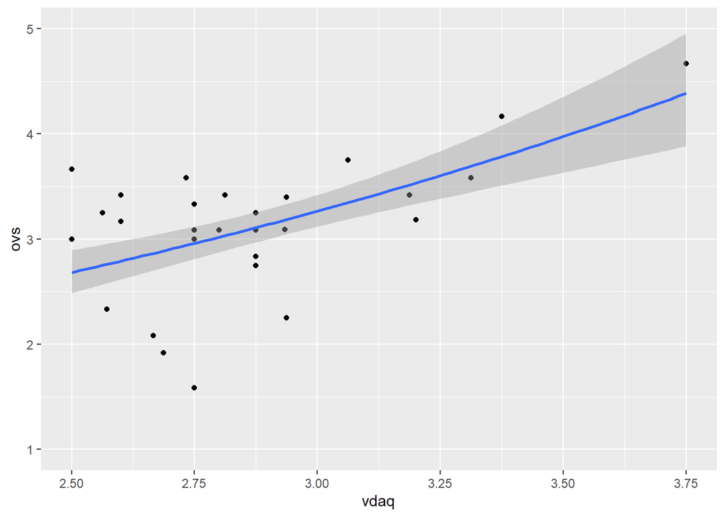

```r
data.30 %>% ggplot() + aes( vdaq,ovs) + geom_point() + stat_smooth(method = "glm", method.args = list(gaussian(link = "log"))) + coord_cartesian(ylim = c(1,5))
```

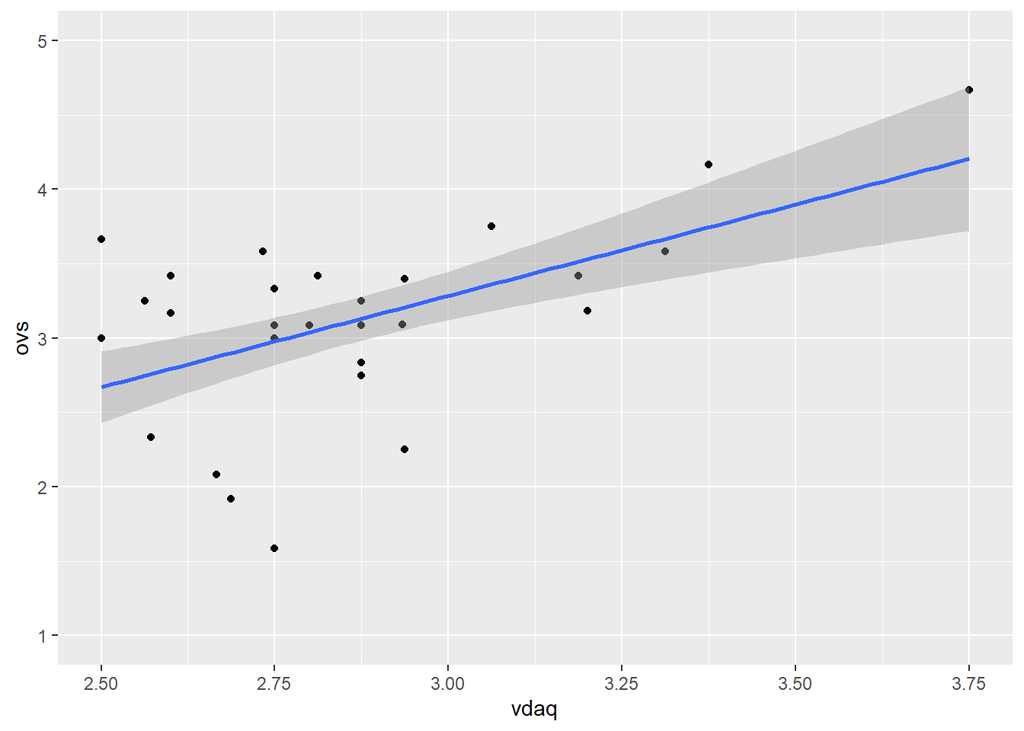

```r
data.30 %>% ggplot() + aes( vdaq, ovs) + geom_point() + stat_smooth(method = "lm")+ coord_cartesian(ylim = c(1,5))
```

# 7 ASQ suhde AOSpan pisteisiin

```r
m_asq_1 <- lmer(Score ~ asq_z + (1|subjectId), data=data.ei_30)
tab_model(m_asq_1)
```

|  | Score |  |  |
| --- | --- | --- | --- |
| Predictors | Estimates | CI | p |
| (Intercept) | 22.58 | 20.07 – 25.09 | **<0.001** |
| asq z | 0.38 | -4.71 – 5.47 | 0.880 |
| Random Effects |  |  |  |
| σ<sup>2</sup> | 5.58 |  |  |
| τ<sub>00</sub> <sub>subjectId</sub> | 24.55 |  |  |
| ICC | 0.81 |  |  |
| N <sub>subjectId</sub> | 18 |  |  |
| Observations | 36 |  |  |
| Marginal R<sup>2</sup> / Conditional R<sup>2</sup> | 0.001 / 0.815 |  |  |

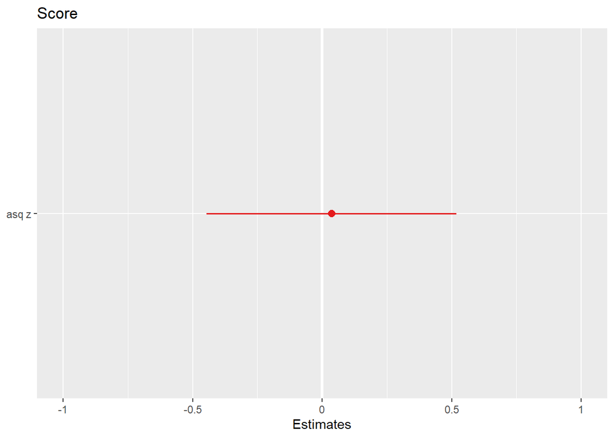

```r
plot_model(m_asq_1, type = "std")
```

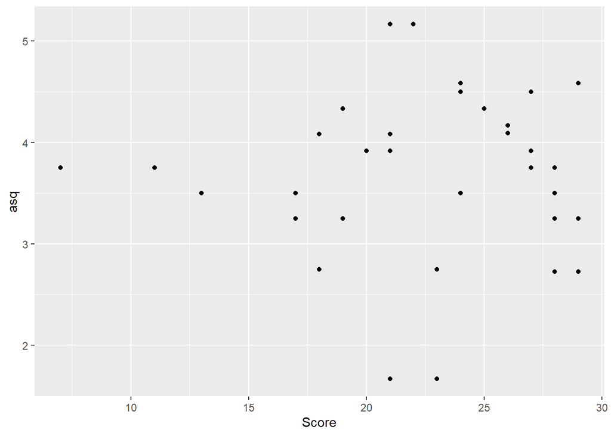

```r
data.ei_30 %>% ggplot() + aes(Score, asq) + geom_point()
```